# Assignment 5: Exploring Yelp Reviews in Philadelphia

In this assignment, we'll explore restaurant review data available through the [Yelp Dataset Challenge](https://www.yelp.com/dataset). The dataset includes Yelp data for user reviews and business information for many metropolitan areas. I've already downloaded this dataset (8 GB total!) and extracted out the data files for reviews and restaurants in Philadelphia. I've placed these data files into the `data` directory in this repository.

This assignment is broken into two parts:

**Part 1:** Analyzing correlations between restaurant reviews and census data

We'll explore the relationship between restaurant reviews and the income levels of the restaurant's surrounding area.

**Part 2:** Exploring the impact of fast food restaurants

We'll run a sentiment analysis on reviews of fast food restaurants and estimate income levels in neighborhoods with fast food restaurants. We'll test how well our sentiment analysis works by comparing the number of stars to the sentiment of reviews.

**Background readings**

- [Does sentiment analysis work?](http://varianceexplained.org/r/yelp-sentiment/)
- [The Geography of Taste: Using Yelp to Study Urban Culture](https://www.mdpi.com/2220-9964/7/9/376/pdf/1)

## 1. Correlating restaurant ratings and income levels

In this part, we'll use the census API to download household income data and explore how it correlates with restaurant review data.

```python
import geopandas as gpd
import holoviews as hv
import hvplot.pandas
import numpy as np
import pandas as pd
import seaborn as sns
from matplotlib import pyplot as plt
import cenpy
import json
!pip install transformers
!pip install torch transformers
```

### 1.1 Query the Census API

Use the `cenpy` package to download **median household income in the past 12 months** by census tract from the 2021 ACS 5-year data set for your county of interest.

You have two options to find the correct variable names:

- Search through: https://api.census.gov/data/2021/acs/acs5/variables.html
- Initialize an API connection and use the `.varslike()` function to search for the proper keywords

At the end of this step, you should have a pandas DataFrame holding the income data for all census tracts within the county being analyzed. Feel free to rename your variable from the ACS so it has a more meaningful name!

::: {.callout-caution} Some census tracts won't have any value because there are not enough households in that tract. The census will use a negative number as a default value for those tracts. You can safely remove those tracts from the analysis! :::

```python
variables = [
    "NAME",
    "B19013_001E"
]
```

```python
acs = cenpy.remote.APIConnection("ACSDT5Y2021")
```

```python
counties = cenpy.explorer.fips_table("COUNTY")
```

```python
philly_county_code = "101"
PA_state_code = "42"
philly_data = acs.query(
    cols=variables,
    geo_unit="block group:*",
    geo_filter={"state": PA_state_code, "county": philly_county_code, "tract": "*"},
)
```

### 1.2 Download census tracts from the Census and merge the data from part 1.1

- Download census tracts for the desired geography using the `pygris` package
- Merge the downloaded census tracts with the household income DataFrame

```python
censustracts = gpd.read_file('Census_Tracts_2010.geojson')
censustracts.rename(columns={'TRACTCE10':'tract'}, inplace=True)
MEDHHINC = gpd.GeoDataFrame(pd.merge(censustracts, philly_data, on='tract')).reset_index(drop=True)
MEDHHINC['B19013_001E'] = pd.to_numeric(MEDHHINC['B19013_001E'], errors='coerce')
MEDHHINC = MEDHHINC[MEDHHINC['B19013_001E'] >= 0]
MEDHHINC.head()
```

|  | OBJECTID | STATEFP10 | COUNTYFP10 | tract | GEOID10 | NAME10 | NAMELSAD10 | MTFCC10 | FUNCSTAT10 | ALAND10 | AWATER10 | INTPTLAT10 | INTPTLON10 | LOGRECNO | geometry | NAME | B19013_001E | state | county | block group |
| --- | --- | --- | --- | --- | --- | --- | --- | --- | --- | --- | --- | --- | --- | --- | --- | --- | --- | --- | --- | --- |
| 0 | 1 | 42 | 101 | 009400 | 42101009400 | 94 | Census Tract 94 | G5020 | S | 366717 | 0 | +39.9632709 | -075.2322437 | 10429 | POLYGON ((-75.22927 39.96054, -75.22865 39.960... | Block Group 1, Census Tract 94, Philadelphia C... | 11012 | 42 | 101 | 1 |
| 1 | 1 | 42 | 101 | 009400 | 42101009400 | 94 | Census Tract 94 | G5020 | S | 366717 | 0 | +39.9632709 | -075.2322437 | 10429 | POLYGON ((-75.22927 39.96054, -75.22865 39.960... | Block Group 2, Census Tract 94, Philadelphia C... | 27019 | 42 | 101 | 2 |
| 2 | 1 | 42 | 101 | 009400 | 42101009400 | 94 | Census Tract 94 | G5020 | S | 366717 | 0 | +39.9632709 | -075.2322437 | 10429 | POLYGON ((-75.22927 39.96054, -75.22865 39.960... | Block Group 3, Census Tract 94, Philadelphia C... | 35457 | 42 | 101 | 3 |
| 6 | 2 | 42 | 101 | 009500 | 42101009500 | 95 | Census Tract 95 | G5020 | S | 319070 | 0 | +39.9658709 | -075.2379140 | 10430 | POLYGON ((-75.23536 39.96852, -75.23545 39.969... | Block Group 3, Census Tract 95, Philadelphia C... | 32839 | 42 | 101 | 3 |
| 7 | 3 | 42 | 101 | 009600 | 42101009600 | 96 | Census Tract 96 | G5020 | S | 405273 | 0 | +39.9655396 | -075.2435075 | 10431 | POLYGON ((-75.24343 39.96230, -75.24339 39.962... | Block Group 1, Census Tract 96, Philadelphia C... | 60271 | 42 | 101 | 1 |

### 1.3 Load the restaurants data

The Yelp dataset includes data for 7,350 restaurants across the city. Load the data from the `data/` folder and use the `latitude` and `longitude` columns to create a GeoDataFrame after loading the JSON data. Be sure to set the right CRS on when initializing the GeoDataFrame!

**Notes**

The JSON data is in a "records" format. To load it, you'll need to pass the following keywords:

- `orient='records'`
- `lines=True`

```python
restaurants = pd.read_json('restaurants_philly.json', orient='records', lines=True)
restaurants = gpd.GeoDataFrame(restaurants,
                               geometry=gpd.points_from_xy(restaurants['longitude'], restaurants['latitude']),
                               crs='EPSG:4326')
restaurants.head()
```

|  | business_id | latitude | longitude | name | review_count | stars | categories | geometry |
| --- | --- | --- | --- | --- | --- | --- | --- | --- |
| 0 | MTSW4McQd7CbVtyjqoe9mw | 39.955505 | -75.155564 | St Honore Pastries | 80 | 4.0 | Restaurants, Food, Bubble Tea, Coffee & Tea, B... | POINT (-75.15556 39.95551) |
| 1 | MUTTqe8uqyMdBl186RmNeA | 39.953949 | -75.143226 | Tuna Bar | 245 | 4.0 | Sushi Bars, Restaurants, Japanese | POINT (-75.14323 39.95395) |
| 2 | ROeacJQwBeh05Rqg7F6TCg | 39.943223 | -75.162568 | BAP | 205 | 4.5 | Korean, Restaurants | POINT (-75.16257 39.94322) |
| 3 | QdN72BWoyFypdGJhhI5r7g | 39.939825 | -75.157447 | Bar One | 65 | 4.0 | Cocktail Bars, Bars, Italian, Nightlife, Resta... | POINT (-75.15745 39.93982) |
| 4 | Mjboz24M9NlBeiOJKLEd_Q | 40.022466 | -75.218314 | DeSandro on Main | 41 | 3.0 | Pizza, Restaurants, Salad, Soup | POINT (-75.21831 40.02247) |

### 1.4 Add tract info for each restaurant

Do a spatial join to identify which census tract each restaurant is within. Make sure each dataframe has the same CRS!

At the end of this step, you should have a new dataframe with a column identifying the tract number for each restaurant.

```python
censustracts = censustracts.to_crs('EPSG:4326')
restaurants = restaurants.to_crs('EPSG:4326')
restaurants_gdf = gpd.sjoin(restaurants, censustracts, how = "left", predicate="within").reset_index(drop=True)
del restaurants_gdf['index_right']
restaurants_gdf.head()
```

|  | business_id | latitude | longitude | name | review_count | stars | categories | geometry | OBJECTID | STATEFP10 | ... | GEOID10 | NAME10 | NAMELSAD10 | MTFCC10 | FUNCSTAT10 | ALAND10 | AWATER10 | INTPTLAT10 | INTPTLON10 | LOGRECNO |
| --- | --- | --- | --- | --- | --- | --- | --- | --- | --- | --- | --- | --- | --- | --- | --- | --- | --- | --- | --- | --- | --- |
| 0 | MTSW4McQd7CbVtyjqoe9mw | 39.955505 | -75.155564 | St Honore Pastries | 80 | 4.0 | Restaurants, Food, Bubble Tea, Coffee & Tea, B... | POINT (-75.15556 39.95551) | 191 | 42 | ... | 42101000200 | 2 | Census Tract 2 | G5020 | S | 382478 | 0 | +39.9553999 | -075.1569775 | 10336 |
| 1 | MUTTqe8uqyMdBl186RmNeA | 39.953949 | -75.143226 | Tuna Bar | 245 | 4.0 | Sushi Bars, Restaurants, Japanese | POINT (-75.14323 39.95395) | 190 | 42 | ... | 42101000100 | 1 | Census Tract 1 | G5020 | S | 704909 | 0 | +39.9523827 | -075.1466628 | 10335 |
| 2 | ROeacJQwBeh05Rqg7F6TCg | 39.943223 | -75.162568 | BAP | 205 | 4.5 | Korean, Restaurants | POINT (-75.16257 39.94322) | 33 | 42 | ... | 42101001500 | 15 | Census Tract 15 | G5020 | S | 239383 | 0 | +39.9419037 | -075.1591158 | 10356 |
| 3 | QdN72BWoyFypdGJhhI5r7g | 39.939825 | -75.157447 | Bar One | 65 | 4.0 | Cocktail Bars, Bars, Italian, Nightlife, Resta... | POINT (-75.15745 39.93982) | 36 | 42 | ... | 42101001800 | 18 | Census Tract 18 | G5020 | S | 242483 | 0 | +39.9399998 | -075.1593091 | 10359 |
| 4 | Mjboz24M9NlBeiOJKLEd_Q | 40.022466 | -75.218314 | DeSandro on Main | 41 | 3.0 | Pizza, Restaurants, Salad, Soup | POINT (-75.21831 40.02247) | 85 | 42 | ... | 42101021000 | 210 | Census Tract 210 | G5020 | S | 858223 | 55719 | +40.0244730 | -075.2151045 | 10536 |

5 rows × 22 columns

### 1.5 Add income data to your restaurant data

Add the income data to your dataframe from the previous step, merging the census data based on the tract that each restaurant is within.

```python
merged_gdf = gpd.sjoin(restaurants_gdf, MEDHHINC, how = "left", predicate="within")
merged_gdf.head()
```

|  | business_id | latitude | longitude | name | review_count | stars | categories | geometry | OBJECTID_left | STATEFP10_left | ... | ALAND10_right | AWATER10_right | INTPTLAT10_right | INTPTLON10_right | LOGRECNO_right | NAME | B19013_001E | state | county | block group |
| --- | --- | --- | --- | --- | --- | --- | --- | --- | --- | --- | --- | --- | --- | --- | --- | --- | --- | --- | --- | --- | --- |
| 0 | MTSW4McQd7CbVtyjqoe9mw | 39.955505 | -75.155564 | St Honore Pastries | 80 | 4.0 | Restaurants, Food, Bubble Tea, Coffee & Tea, B... | POINT (-75.15556 39.95551) | 191 | 42 | ... | 382478.0 | 0.0 | +39.9553999 | -075.1569775 | 10336 | Block Group 1, Census Tract 2, Philadelphia Co... | 42308.0 | 42 | 101 | 1 |
| 0 | MTSW4McQd7CbVtyjqoe9mw | 39.955505 | -75.155564 | St Honore Pastries | 80 | 4.0 | Restaurants, Food, Bubble Tea, Coffee & Tea, B... | POINT (-75.15556 39.95551) | 191 | 42 | ... | 382478.0 | 0.0 | +39.9553999 | -075.1569775 | 10336 | Block Group 2, Census Tract 2, Philadelphia Co... | 250001.0 | 42 | 101 | 2 |
| 1 | MUTTqe8uqyMdBl186RmNeA | 39.953949 | -75.143226 | Tuna Bar | 245 | 4.0 | Sushi Bars, Restaurants, Japanese | POINT (-75.14323 39.95395) | 190 | 42 | ... | NaN | NaN | NaN | NaN | NaN | NaN | NaN | NaN | NaN | NaN |
| 2 | ROeacJQwBeh05Rqg7F6TCg | 39.943223 | -75.162568 | BAP | 205 | 4.5 | Korean, Restaurants | POINT (-75.16257 39.94322) | 33 | 42 | ... | 239383.0 | 0.0 | +39.9419037 | -075.1591158 | 10356 | Block Group 1, Census Tract 15, Philadelphia C... | 66290.0 | 42 | 101 | 1 |
| 2 | ROeacJQwBeh05Rqg7F6TCg | 39.943223 | -75.162568 | BAP | 205 | 4.5 | Korean, Restaurants | POINT (-75.16257 39.94322) | 33 | 42 | ... | 239383.0 | 0.0 | +39.9419037 | -075.1591158 | 10356 | Block Group 2, Census Tract 15, Philadelphia C... | 107292.0 | 42 | 101 | 2 |

5 rows × 42 columns

### 1.6 Make a plot of median household income vs. Yelp stars

Our dataset has the number of stars for each restaurant, rounded to the nearest 0.5 star. In this step, create a line plot that shows the average income value for each stars category (e.g., all restaurants with 1 star, 1.5 stars, 2 stars, etc.)

While their are multiple ways to do this, the [seaborn.lineplot()](https://seaborn.pydata.org/generated/seaborn.lineplot.html) is a great option. This can show the average value in each category as well as 95% uncertainty intervals. Use this function to plot the stars ("x") vs. average income ("y") for all of our restaurants, using the dataframe from last step. Be sure to format your figure to make it look nice!

**Question:** Is there a correlation between a restaurant's ratings and the income levels of its surrounding neighborhood?

```python
grouped_df = merged_gdf.groupby('stars')['B19013_001E'].mean().reset_index()
grouped_df.head()
```

|  | stars | B19013_001E |
| --- | --- | --- |
| 0 | 1.0 | 55197.340659 |
| 1 | 1.5 | 59296.992105 |
| 2 | 2.0 | 65606.081140 |
| 3 | 2.5 | 71007.582278 |
| 4 | 3.0 | 75801.154528 |

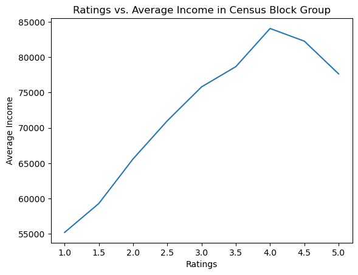

```python
ax = sns.lineplot(
    data=grouped_df,
    x='stars',
    y='B19013_001E',
    estimator= 'mean',
    errorbar=('ci', 95))
ax.set(xlabel='Ratings', ylabel='Average Income')
ax.set_title('Ratings vs. Average Income in Census Block Group')
```

## 2. Fast food trends in Philadelphia

At the end of part 1, you should have seen a strong trend where higher income tracts generally had restaurants with better reviews. In this section, we'll explore the impact of fast food restaurants and how they might be impacting this trend.

**Hypothesis**

1. Fast food restaurants are predominantly located in areas with lower median income levels.
2. Fast food restaurants have worse reviews compared to typical restaurants.

If true, these two hypotheses could help to explain the trend we found in part 1. Let's dive in and test our hypotheses!

### 2.1 Identify fast food restaurants

The "categories" column in our dataset contains multiple classifications for each restaurant. One such category is "Fast Food". In this step, add a new column called "is_fast_food" that is `True` if the "categories" column contains the term "Fast Food" and `False` otherwise

```python
merged_gdf['is_fast_food'] = merged_gdf['categories'].str.contains('Fast Food', case=False)
merged_gdf.head()
```

|  | business_id | latitude | longitude | name | review_count | stars | categories | geometry | OBJECTID_left | STATEFP10_left | ... | AWATER10_right | INTPTLAT10_right | INTPTLON10_right | LOGRECNO_right | NAME | B19013_001E | state | county | block group | is_fast_food |
| --- | --- | --- | --- | --- | --- | --- | --- | --- | --- | --- | --- | --- | --- | --- | --- | --- | --- | --- | --- | --- | --- |
| 0 | MTSW4McQd7CbVtyjqoe9mw | 39.955505 | -75.155564 | St Honore Pastries | 80 | 4.0 | Restaurants, Food, Bubble Tea, Coffee & Tea, B... | POINT (-75.15556 39.95551) | 191 | 42 | ... | 0.0 | +39.9553999 | -075.1569775 | 10336 | Block Group 1, Census Tract 2, Philadelphia Co... | 42308.0 | 42 | 101 | 1 | False |
| 0 | MTSW4McQd7CbVtyjqoe9mw | 39.955505 | -75.155564 | St Honore Pastries | 80 | 4.0 | Restaurants, Food, Bubble Tea, Coffee & Tea, B... | POINT (-75.15556 39.95551) | 191 | 42 | ... | 0.0 | +39.9553999 | -075.1569775 | 10336 | Block Group 2, Census Tract 2, Philadelphia Co... | 250001.0 | 42 | 101 | 2 | False |
| 1 | MUTTqe8uqyMdBl186RmNeA | 39.953949 | -75.143226 | Tuna Bar | 245 | 4.0 | Sushi Bars, Restaurants, Japanese | POINT (-75.14323 39.95395) | 190 | 42 | ... | NaN | NaN | NaN | NaN | NaN | NaN | NaN | NaN | NaN | False |
| 2 | ROeacJQwBeh05Rqg7F6TCg | 39.943223 | -75.162568 | BAP | 205 | 4.5 | Korean, Restaurants | POINT (-75.16257 39.94322) | 33 | 42 | ... | 0.0 | +39.9419037 | -075.1591158 | 10356 | Block Group 1, Census Tract 15, Philadelphia C... | 66290.0 | 42 | 101 | 1 | False |
| 2 | ROeacJQwBeh05Rqg7F6TCg | 39.943223 | -75.162568 | BAP | 205 | 4.5 | Korean, Restaurants | POINT (-75.16257 39.94322) | 33 | 42 | ... | 0.0 | +39.9419037 | -075.1591158 | 10356 | Block Group 2, Census Tract 15, Philadelphia C... | 107292.0 | 42 | 101 | 2 | False |

5 rows × 43 columns

### 2.2 Calculate the median income for fast food and otherwise

Group by the "is_fast_food" column and calculate the median income for restaurants that are and are not fast food. You should find that income levels are lower in tracts with fast food.

*Note:* this is just an estimate, since we are calculating a median of median income values.

```python
grouped_gdf2 = merged_gdf.groupby('is_fast_food')['B19013_001E'].median().reset_index()
grouped_gdf2.head()
```

|  | is_fast_food | B19013_001E |
| --- | --- | --- |
| 0 | False | 69783.0 |
| 1 | True | 55773.5 |

### 2.3 Load fast food review data

In the rest of part 2, we're going to run a sentiment analysis on the reviews for fast food restaurants. The review data for all fast food restaurants identified in part 2.1 is already stored in the `data/` folder. The data is stored as a JSON file and you can use `pandas.read_json` to load it.

**Notes**

The JSON data is in a "records" format. To load it, you'll need to pass the following keywords:

- `orient='records'`
- `lines=True`

```python
reviews = pd.read_json('reviews_philly_fast_food.json', orient='records', lines=True)
merged_gdf
```

|  | business_id | latitude | longitude | name | review_count | stars | categories | geometry | OBJECTID_left | STATEFP10_left | ... | AWATER10_right | INTPTLAT10_right | INTPTLON10_right | LOGRECNO_right | NAME | B19013_001E | state | county | block group | is_fast_food |
| --- | --- | --- | --- | --- | --- | --- | --- | --- | --- | --- | --- | --- | --- | --- | --- | --- | --- | --- | --- | --- | --- |
| 0 | MTSW4McQd7CbVtyjqoe9mw | 39.955505 | -75.155564 | St Honore Pastries | 80 | 4.0 | Restaurants, Food, Bubble Tea, Coffee & Tea, B... | POINT (-75.15556 39.95551) | 191 | 42 | ... | 0.0 | +39.9553999 | -075.1569775 | 10336 | Block Group 1, Census Tract 2, Philadelphia Co... | 42308.0 | 42 | 101 | 1 | False |
| 0 | MTSW4McQd7CbVtyjqoe9mw | 39.955505 | -75.155564 | St Honore Pastries | 80 | 4.0 | Restaurants, Food, Bubble Tea, Coffee & Tea, B... | POINT (-75.15556 39.95551) | 191 | 42 | ... | 0.0 | +39.9553999 | -075.1569775 | 10336 | Block Group 2, Census Tract 2, Philadelphia Co... | 250001.0 | 42 | 101 | 2 | False |
| 1 | MUTTqe8uqyMdBl186RmNeA | 39.953949 | -75.143226 | Tuna Bar | 245 | 4.0 | Sushi Bars, Restaurants, Japanese | POINT (-75.14323 39.95395) | 190 | 42 | ... | NaN | NaN | NaN | NaN | NaN | NaN | NaN | NaN | NaN | False |
| 2 | ROeacJQwBeh05Rqg7F6TCg | 39.943223 | -75.162568 | BAP | 205 | 4.5 | Korean, Restaurants | POINT (-75.16257 39.94322) | 33 | 42 | ... | 0.0 | +39.9419037 | -075.1591158 | 10356 | Block Group 1, Census Tract 15, Philadelphia C... | 66290.0 | 42 | 101 | 1 | False |
| 2 | ROeacJQwBeh05Rqg7F6TCg | 39.943223 | -75.162568 | BAP | 205 | 4.5 | Korean, Restaurants | POINT (-75.16257 39.94322) | 33 | 42 | ... | 0.0 | +39.9419037 | -075.1591158 | 10356 | Block Group 2, Census Tract 15, Philadelphia C... | 107292.0 | 42 | 101 | 2 | False |
| ... | ... | ... | ... | ... | ... | ... | ... | ... | ... | ... | ... | ... | ... | ... | ... | ... | ... | ... | ... | ... | ... |
| 7348 | 8n93L-ilMAsvwUatarykSg | 39.951018 | -75.198240 | Kitchen Gia | 22 | 3.0 | Coffee & Tea, Food, Sandwiches, American (Trad... | POINT (-75.19824 39.95102) | 378 | 42 | ... | NaN | NaN | NaN | NaN | NaN | NaN | NaN | NaN | NaN | False |
| 7349 | WnT9NIzQgLlILjPT0kEcsQ | 39.935982 | -75.158665 | Adelita Taqueria & Restaurant | 35 | 4.5 | Restaurants, Mexican | POINT (-75.15866 39.93598) | 42 | 42 | ... | 0.0 | +39.9367634 | -075.1595100 | 10365 | Block Group 1, Census Tract 24, Philadelphia C... | 117500.0 | 42 | 101 | 1 | False |
| 7349 | WnT9NIzQgLlILjPT0kEcsQ | 39.935982 | -75.158665 | Adelita Taqueria & Restaurant | 35 | 4.5 | Restaurants, Mexican | POINT (-75.15866 39.93598) | 42 | 42 | ... | 0.0 | +39.9367634 | -075.1595100 | 10365 | Block Group 2, Census Tract 24, Philadelphia C... | 135139.0 | 42 | 101 | 2 | False |
| 7349 | WnT9NIzQgLlILjPT0kEcsQ | 39.935982 | -75.158665 | Adelita Taqueria & Restaurant | 35 | 4.5 | Restaurants, Mexican | POINT (-75.15866 39.93598) | 42 | 42 | ... | 0.0 | +39.9367634 | -075.1595100 | 10365 | Block Group 3, Census Tract 24, Philadelphia C... | 66313.0 | 42 | 101 | 3 | False |
| 7349 | WnT9NIzQgLlILjPT0kEcsQ | 39.935982 | -75.158665 | Adelita Taqueria & Restaurant | 35 | 4.5 | Restaurants, Mexican | POINT (-75.15866 39.93598) | 42 | 42 | ... | 0.0 | +39.9367634 | -075.1595100 | 10365 | Block Group 4, Census Tract 24, Philadelphia C... | 82606.0 | 42 | 101 | 4 | False |

17818 rows × 43 columns

### 2.4 Trim to the most popular fast food restaurants

There's too many reviews to run a sentiment analysis on all of them in a reasonable time. Let's trim our reviews dataset to the most popular fast food restaurants, using the list provided below.

You will need to get the "business_id" values for each of these restaurants from the restaurants data loaded in part 1.3. Then, trim the reviews data to include reviews only for those business IDs.

```python
popular_fast_food = [
    "McDonald's",
    "Wendy's",
    "Subway",
    "Popeyes Louisiana Kitchen",
    "Taco Bell",
    "KFC",
    "Burger King",
]
```

```python
business_id = merged_gdf[['business_id','name']]
reviews = pd.merge(business_id, reviews, on = 'business_id')
reviews.head()
```

|  | business_id | name | review_id | stars | text |
| --- | --- | --- | --- | --- | --- |
| 0 | O1oZpbZNDMH_gz8DhsZCdA | Wendy's | WtP3kl8xVOcoJOYyxkGfIg | 1 | This Wendy's is the worst Wendy's to go to . T... |
| 1 | O1oZpbZNDMH_gz8DhsZCdA | Wendy's | 7l__He_d8pHrEAAZZv2l0Q | 1 | This location has the slowest service ever eve... |
| 2 | O1oZpbZNDMH_gz8DhsZCdA | Wendy's | WSIe14YeSYUYqTdx6UDoFw | 1 | I got a burnt baked potato no friends ! Cook ... |
| 3 | O1oZpbZNDMH_gz8DhsZCdA | Wendy's | kc9ABqXrw1-91xP6G0KWmQ | 1 | The restaurant was extremely dirty. All the ta... |
| 4 | O1oZpbZNDMH_gz8DhsZCdA | Wendy's | ekdJfqlBxQf5oaZvaKQ8Zg | 1 | Eww I dont like Wendy's it looks nasty as hell... |

```python
reviews_filtered = reviews[reviews['name'].isin(popular_fast_food)]
reviews_filtered.head()
```

|  | business_id | name | review_id | stars | text |
| --- | --- | --- | --- | --- | --- |
| 0 | O1oZpbZNDMH_gz8DhsZCdA | Wendy's | WtP3kl8xVOcoJOYyxkGfIg | 1 | This Wendy's is the worst Wendy's to go to . T... |
| 1 | O1oZpbZNDMH_gz8DhsZCdA | Wendy's | 7l__He_d8pHrEAAZZv2l0Q | 1 | This location has the slowest service ever eve... |
| 2 | O1oZpbZNDMH_gz8DhsZCdA | Wendy's | WSIe14YeSYUYqTdx6UDoFw | 1 | I got a burnt baked potato no friends ! Cook ... |
| 3 | O1oZpbZNDMH_gz8DhsZCdA | Wendy's | kc9ABqXrw1-91xP6G0KWmQ | 1 | The restaurant was extremely dirty. All the ta... |
| 4 | O1oZpbZNDMH_gz8DhsZCdA | Wendy's | ekdJfqlBxQf5oaZvaKQ8Zg | 1 | Eww I dont like Wendy's it looks nasty as hell... |

### 2.5 Run the emotions classifier on fast food reviews

Run a sentiment analysis on the reviews data from the previous step. Use the [DistilBERT model](https://huggingface.co/bhadresh-savani/distilbert-base-uncased-emotion) that can predict emotion labels (anger, fear, sadness, joy, love, and surprise). Transform the result from the classifier into a DataFrame so that you have a column for each of the emotion labels.

```python
from transformers import pipeline
import torch
```

```python
text_data = reviews_filtered['text'].tolist()

model = "bhadresh-savani/distilbert-base-uncased-emotion"

emotion_classifier = pipeline(
    task="text-classification",
    model=model,
    tokenizer=model,
    truncation=True,
)

emotion_scores = emotion_classifier(text_data)
```

```python
emotion_df = pd.DataFrame(emotion_scores)
emotion_df['text'] = text_data
```

```python
print(emotion_df.columns)
```

```
Index(['label', 'score', 'text'], dtype='object')
```

### 2.6 Identify the predicted emotion for each text

Use the pandas [idxmax()](https://pandas.pydata.org/pandas-docs/stable/reference/api/pandas.DataFrame.idxmax.html) to identify the predicted emotion for each review, and add this value to a new column called "prediction"

The predicted emotion has the highest confidence score across all emotion labels for a particular label.

```python
emotion_df_no_duplicates = emotion_df.drop_duplicates(subset='text')


emotion_pivot = emotion_df_no_duplicates.pivot(index='text', columns='label', values='score').reset_index()


emotion_pivot.columns.name = None  # Remove the 'label' name for columns


emotion_pivot.head()
```

|  | text | anger | fear | joy | love | sadness | surprise |
| --- | --- | --- | --- | --- | --- | --- | --- |
| 0 | "Meh. I've experienced better." That's what ... | NaN | NaN | 0.997238 | NaN | NaN | NaN |
| 1 | "No burgers in Burger King!" I went to this Bu... | NaN | NaN | NaN | 0.881435 | NaN | NaN |
| 2 | "Open 24 hours"... or when we feel like it. Th... | NaN | NaN | NaN | NaN | 0.994735 | NaN |
| 3 | "Why the fuck you add salad dressing to the ba... | 0.997625 | NaN | NaN | NaN | NaN | NaN |
| 4 | $.69 for any size coffee you say? Breakfast s... | NaN | NaN | NaN | NaN | 0.898883 | NaN |

```python
FF_emotions = pd.merge(reviews_filtered, emotion_pivot, on='text', how='left')

FF_emotions['prediction'] = FF_emotions[['anger', 'fear', 'sadness', 'joy', 'surprise', 'love']].idxmax(axis=1)

FF_emotions.head()
```

|  | business_id | name | review_id | stars | text | anger | fear | joy | love | sadness | surprise | prediction |
| --- | --- | --- | --- | --- | --- | --- | --- | --- | --- | --- | --- | --- |
| 0 | O1oZpbZNDMH_gz8DhsZCdA | Wendy's | WtP3kl8xVOcoJOYyxkGfIg | 1 | This Wendy's is the worst Wendy's to go to . T... | NaN | NaN | NaN | NaN | 0.995998 | NaN | sadness |
| 1 | O1oZpbZNDMH_gz8DhsZCdA | Wendy's | 7l__He_d8pHrEAAZZv2l0Q | 1 | This location has the slowest service ever eve... | 0.646855 | NaN | NaN | NaN | NaN | NaN | anger |
| 2 | O1oZpbZNDMH_gz8DhsZCdA | Wendy's | WSIe14YeSYUYqTdx6UDoFw | 1 | I got a burnt baked potato no friends ! Cook ... | 0.890414 | NaN | NaN | NaN | NaN | NaN | anger |
| 3 | O1oZpbZNDMH_gz8DhsZCdA | Wendy's | kc9ABqXrw1-91xP6G0KWmQ | 1 | The restaurant was extremely dirty. All the ta... | NaN | NaN | NaN | NaN | 0.642099 | NaN | sadness |
| 4 | O1oZpbZNDMH_gz8DhsZCdA | Wendy's | ekdJfqlBxQf5oaZvaKQ8Zg | 1 | Eww I dont like Wendy's it looks nasty as hell... | 0.986700 | NaN | NaN | NaN | NaN | NaN | anger |

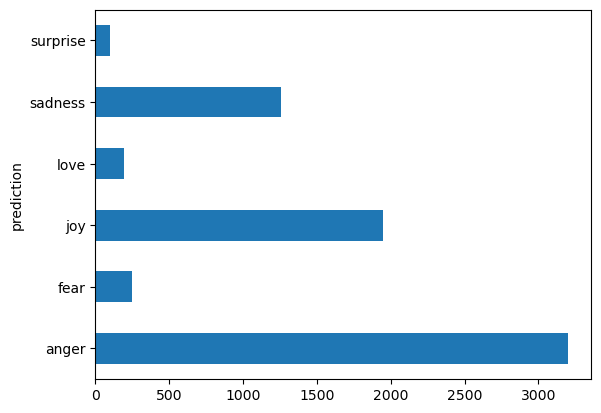

```python
FF_emotions.groupby("prediction").size().plot(kind='barh');
```

### 2.7 Combine the ratings and sentiment data

Combine the data from part 2.4 (reviews data) and part 2.6 (emotion data). Use the `pd.concat()` function and combine along the column axis.

**Note:** You'll need to reset the index of your reviews data frame so it matches the emotion data index (it should run from 0 to the length of the data - 1).

```python
FF_reviews_reset = reviews_filtered.reset_index(drop=True)

emotion_data_subset = FF_emotions[['anger', 'fear', 'joy', 'love', 'sadness', 'surprise', 'prediction']]

rating_sentiment = pd.concat([FF_reviews_reset, emotion_data_subset], axis=1)

print(rating_sentiment.head())
```

```
              business_id     name               review_id  stars  \
0  O1oZpbZNDMH_gz8DhsZCdA  Wendy's  WtP3kl8xVOcoJOYyxkGfIg      1
1  O1oZpbZNDMH_gz8DhsZCdA  Wendy's  7l__He_d8pHrEAAZZv2l0Q      1
2  O1oZpbZNDMH_gz8DhsZCdA  Wendy's  WSIe14YeSYUYqTdx6UDoFw      1
3  O1oZpbZNDMH_gz8DhsZCdA  Wendy's  kc9ABqXrw1-91xP6G0KWmQ      1
4  O1oZpbZNDMH_gz8DhsZCdA  Wendy's  ekdJfqlBxQf5oaZvaKQ8Zg      1

                                                text     anger  fear  joy  \
0  This Wendy's is the worst Wendy's to go to . T...       NaN   NaN  NaN
1  This location has the slowest service ever eve...  0.646855   NaN  NaN
2  I got a burnt baked potato  no friends ! Cook ...  0.890414   NaN  NaN
3  The restaurant was extremely dirty. All the ta...       NaN   NaN  NaN
4  Eww I dont like Wendy's it looks nasty as hell...  0.986700   NaN  NaN

   love   sadness  surprise prediction
0   NaN  0.995998       NaN    sadness
1   NaN       NaN       NaN      anger
2   NaN       NaN       NaN      anger
3   NaN  0.642099       NaN    sadness
4   NaN       NaN       NaN      anger
```

### 2.8 Plot sentiment vs. stars

We now have a dataframe with the predicted primary emotion for each review and the associated number of stars for each review. Let's explore two questions:

1. Does sentiment analysis work? Do reviews with fewer stars have negative emotions?
2. For our fast food restaurants, are reviews generally positive or negative?

Use seaborn's [histplot()](https://seaborn.pydata.org/generated/seaborn.histplot.html) to make a stacked bar chart showing the breakdown of each emotion for each stars category (1 star, 2 stars, etc.). A few notes:

- To stack multiple emotion labels in one bar, use the `multiple="stack"` keyword
- The `discrete=True` can be helpful to tell seaborn our stars values are discrete categories

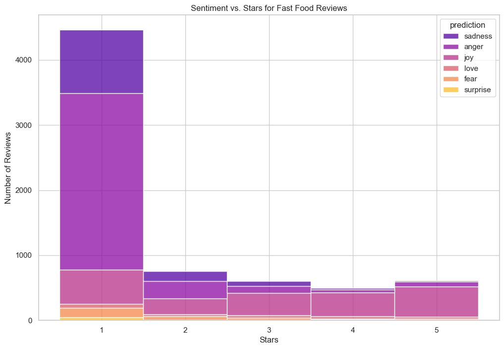

```python
sns.set(style="whitegrid")


plt.figure(figsize=(12, 8))
sns.histplot(data=rating_sentiment, x='stars', hue='prediction', multiple="stack", discrete=True, palette='plasma')


plt.xlabel('Stars')
plt.ylabel('Number of Reviews')
plt.title('Sentiment vs. Stars for Fast Food Reviews')


plt.show()
```